# Project 1: Can you feel the emotion of music?

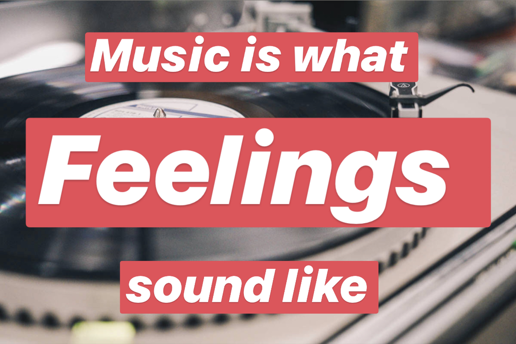

Music is everywhere around us. Have you ever open music apps when you have some emotions? Or is there any feeling coming to your mind when you are listening to music? I bet both are your situations! Melody and lyrics are both essential for a song. Good lyrics lead to strong emontions. Using lyrics data, which contains songs’ names, years, artists，music genres and lyrics, let’s find out the sentiments of songs and lyrics.

## Basic sentiment analysis

There are several sentiment dictionaries built in R for evaluating the words emotions in text. The nrc lexicon categorizes words into categories of positive, negative, anger, anticipation, disgust, fear, joy, sadness, surprise, and trust. The bing lexicon categorizes words into positive and negative. The AFINN lexicon assigns words with a score between -5 and 5, with negative scores representing negative sentiment and positive scores for positive sentiment. First, I should find whether the words are positive or negative and what the words are.Then, I use bing lexicon to get the dictionary and then match the words with our dataset.

### Find negative and positive words in lyrics

Using all the stemmed lyrics from dataset, the top 10 most frequent negative words and positive words are as follows:

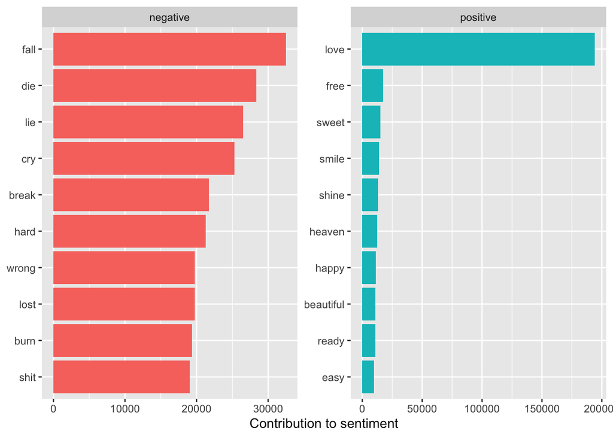

For negative words in all the lyrics, a song writer tends to use words like fall, die, lie, cry and so on to represent their negative feelings. And for postive sentiments, love is the most obvious word that artists use compared to all the others. Since after a quick look of the lyrics shinny app provided by our instrutor, it is not hard to find most songs contain the word love, which means love is a common topic and also the common positive sentiment in music.

The positive and negative wordclouds are as follows, which gives us a more straightforward visualization of the most commoon sentimental words among the lyric words.

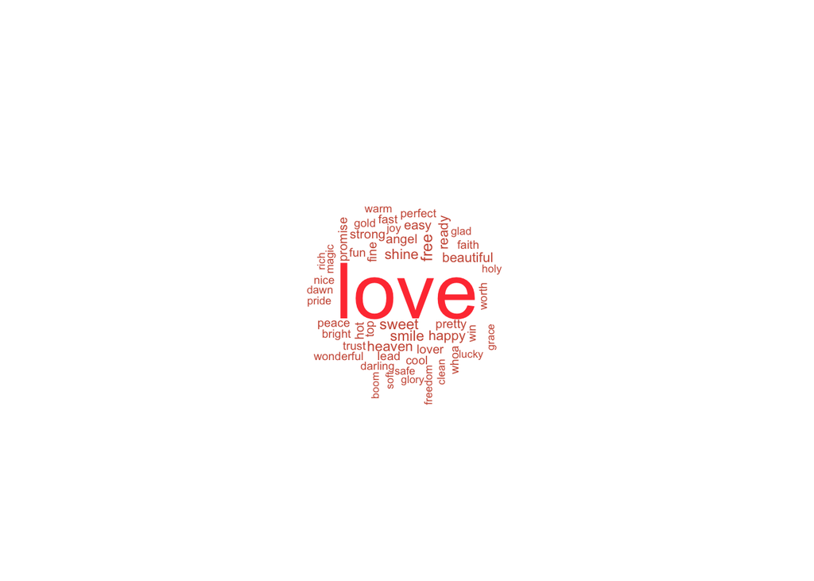

*Positive wordcloud*

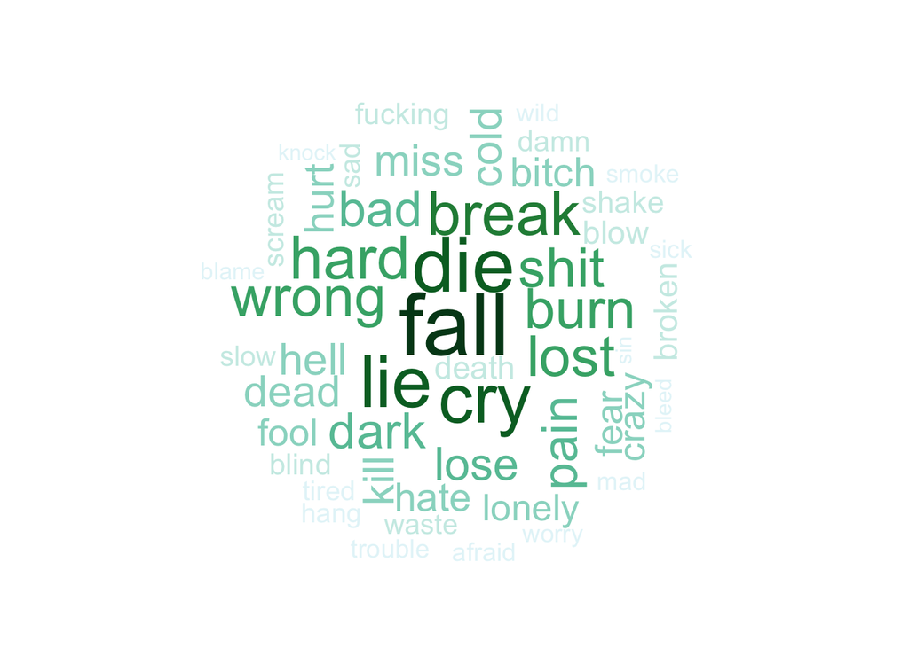

*Negative wordcloud*

The total number of postive words in the stemmed lyrics using bing lexicon is:

```
## [1] 752580
```

The total number of negative words in the stemmed lyrics using bing lexicon is:

```
## [1] 1215583
```

From the numbers calculated, I find negative words are more than positive words in lyrics. This result is in accord with our common sense that artists create music mostly when they have bad feelings and music is a way to speak it out.

## Statistical tests

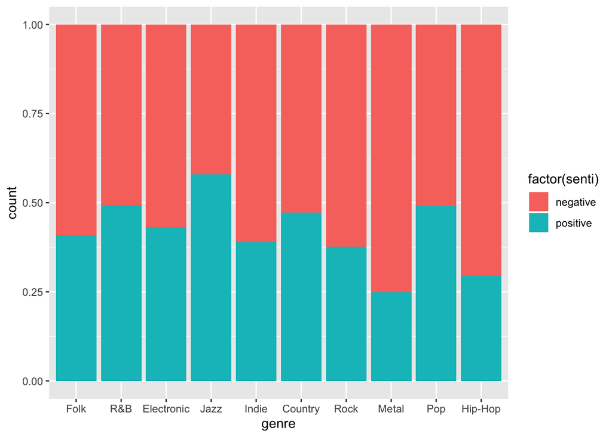

Since the bar chart shows the sentiments of songs could be different among those genres, however, will the statistical tests give us the same conclusion? First , I use Afinn lexicon to give a score to each words in the songs and then take mean as the sentiment score to evaluate the sentiment of the whole song. To test whether the sentiment ditributions or means for the genres are the same, first, we should see the normality of data and decide whether we can use t test. This is a histgram for sentiment scores of country genre.

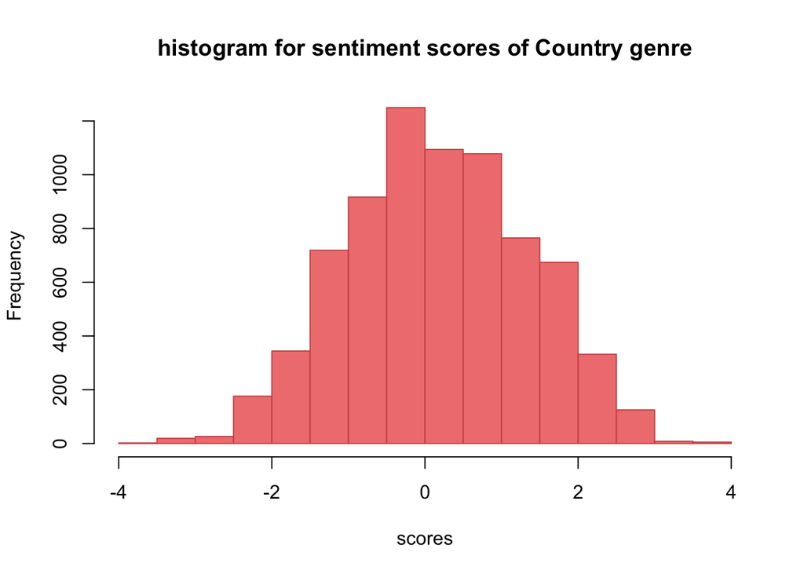

It seems like a normal distribution but I am not sure about it. Thus, I use k-s test to examine the normality.

```
##
##  One-sample Kolmogorov-Smirnov test
##
## data:  lyrics1$score[lyrics1$genre == "Country"]
## D = 0.12566, p-value < 2.2e-16
## alternative hypothesis: two-sided
```

```
##                 Df Sum Sq Mean Sq F value Pr(>F)
## genre1           9  15668  1740.9    1240 <2e-16 ***
## Residuals   122222 171544     1.4
## ---
## Signif. codes:  0 '***' 0.001 '**' 0.01 '*' 0.05 '.' 0.1 ' ' 1
```

```
##   Tukey multiple comparisons of means
##     95% family-wise confidence level
##
## Fit: aov(formula = score ~ genre1, data = lyrics1)
##
## $genre1
##                           diff         lwr         upr     p adj
## R&B-Folk            0.24342682  0.05959975  0.42725389 0.0011593
## Electronic-Folk    -0.05162081 -0.23141600  0.12817438 0.9962587
## Jazz-Folk           0.62600700  0.45068261  0.80133138 0.0000000
## Indie-Folk         -0.12670563 -0.32161361  0.06820235 0.5584911
## Country-Folk        0.21913638  0.04827033  0.39000243 0.0020197
## Rock-Folk          -0.18678076 -0.35275437 -0.02080714 0.0136170
## Metal-Folk         -0.77337682 -0.94241105 -0.60434258 0.0000000
## Pop-Folk            0.22042914  0.05285245  0.38800584 0.0013059
## Hip-Hop-Folk       -0.88118336 -1.05120729 -0.71115944 0.0000000
## Electronic-R&B     -0.29504763 -0.40208732 -0.18800793 0.0000000
## Jazz-R&B            0.38258018  0.28323318  0.48192718 0.0000000
## Indie-R&B          -0.37013245 -0.50097705 -0.23928785 0.0000000
## Country-R&B        -0.02429043 -0.11553951  0.06695864 0.9979083
## Rock-R&B           -0.43020757 -0.51192922 -0.34848593 0.0000000
## Metal-R&B          -1.01680363 -1.10457470 -0.92903257 0.0000000
## Pop-R&B            -0.02299767 -0.10792786  0.06193251 0.9976119
## Hip-Hop-R&B        -1.12461018 -1.21427244 -1.03494791 0.0000000
## Jazz-Electronic     0.67762781  0.58595587  0.76929975 0.0000000
## Indie-Electronic   -0.07508482 -0.20020168  0.05003204 0.6701359
## Country-Electronic  0.27075719  0.18793019  0.35358419 0.0000000
## Rock-Electronic    -0.13515995 -0.20735653 -0.06296337 0.0000001
## Metal-Electronic   -0.72175601 -0.80073498 -0.64277703 0.0000000
## Pop-Electronic      0.27204995  0.19624062  0.34785928 0.0000000
## Hip-Hop-Electronic -0.82956255 -0.91063807 -0.74848703 0.0000000
## Indie-Jazz         -0.75271263 -0.87131515 -0.63411011 0.0000000
## Country-Jazz       -0.40687061 -0.47948357 -0.33425766 0.0000000
## Rock-Jazz          -0.81278775 -0.87299304 -0.75258247 0.0000000
## Metal-Jazz         -1.39938381 -1.46757478 -1.33119285 0.0000000
## Pop-Jazz           -0.40557785 -0.47007114 -0.34108457 0.0000000
## Hip-Hop-Jazz       -1.50719036 -1.57779893 -1.43658179 0.0000000
## Country-Indie       0.34584201  0.23393525  0.45774878 0.0000000
## Rock-Indie         -0.06007513 -0.16435916  0.04420890 0.7210092
## Metal-Indie        -0.64667119 -0.75576056 -0.53758181 0.0000000
## Pop-Indie           0.34713477  0.24031779  0.45395175 0.0000000
## Hip-Hop-Indie      -0.75447773 -0.86509443 -0.64386104 0.0000000
## Rock-Country       -0.40591714 -0.45153778 -0.36029650 0.0000000
## Metal-Country      -0.99251320 -1.04824986 -0.93677654 0.0000000
## Pop-Country         0.00129276 -0.04985361  0.05243913 1.0000000
## Hip-Hop-Country    -1.10031974 -1.15898947 -1.04165002 0.0000000
## Metal-Rock         -0.58659606 -0.62478780 -0.54840431 0.0000000
## Pop-Rock            0.40720990  0.37609744  0.43832236 0.0000000
## Hip-Hop-Rock       -0.69440260 -0.73676026 -0.65204494 0.0000000
## Pop-Metal           0.99380596  0.94915938  1.03845254 0.0000000
## Hip-Hop-Metal      -0.10780655 -0.16090554 -0.05470755 0.0000000
## Hip-Hop-Pop        -1.10161250 -1.14987097 -1.05335404 0.0000000
```

```
##
##  Pearson's Chi-squared test
##
## data:  mytable1
## X-squared = 7587.4, df = 18, p-value < 2.2e-16
```

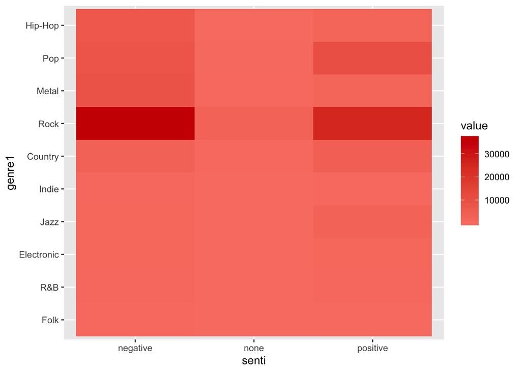

### sentiments among different ages

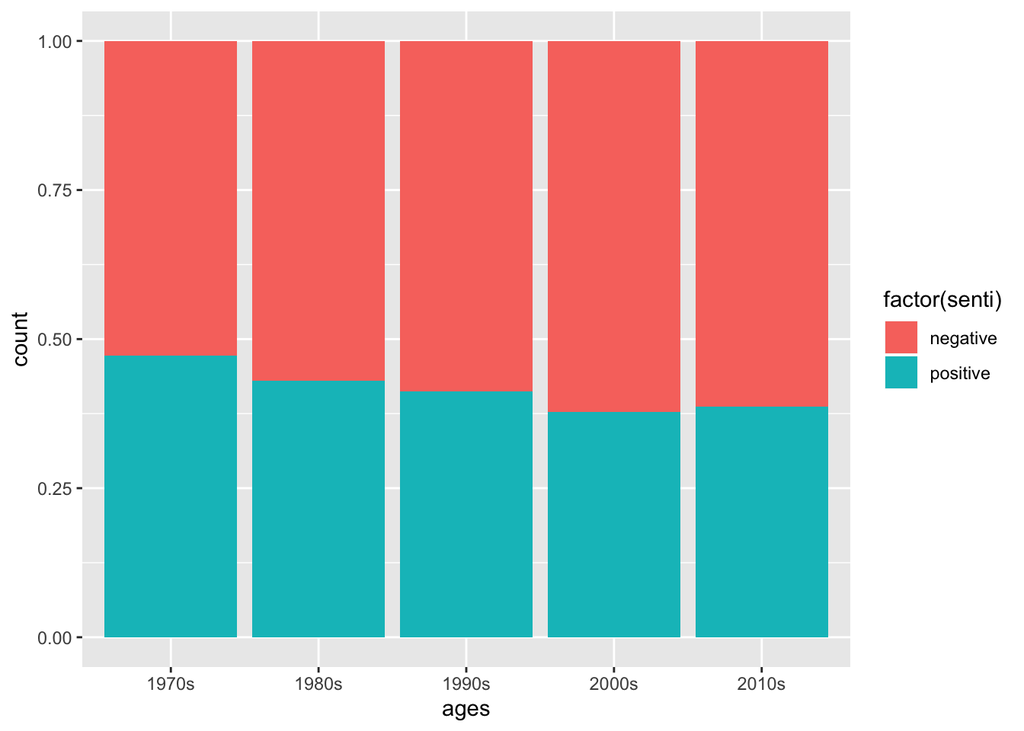

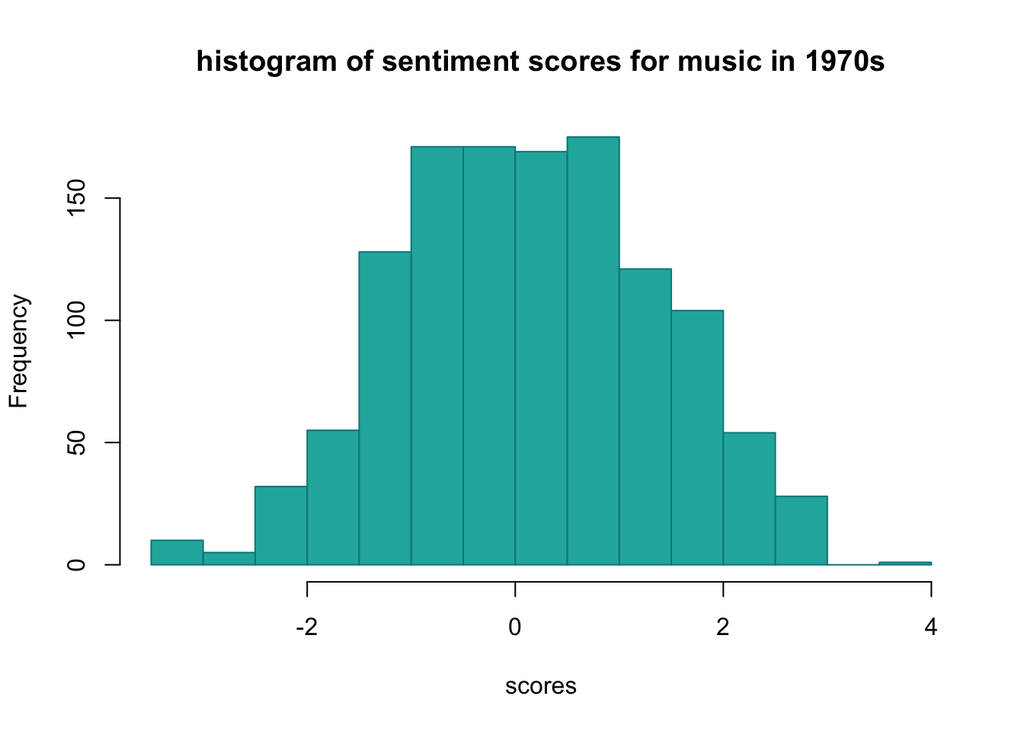

```
##
##  One-sample Kolmogorov-Smirnov test
##
## data:  lyrics2$score[lyrics2$ages == "1970s"]
## D = 0.13138, p-value < 2.2e-16
## alternative hypothesis: two-sided
```

```
##                 Df Sum Sq Mean Sq F value Pr(>F)
## ages             4    255   63.74   41.62 <2e-16 ***
## Residuals   125696 192504    1.53
## ---
## Signif. codes:  0 '***' 0.001 '**' 0.01 '*' 0.05 '.' 0.1 ' ' 1
```

```
##   Tukey multiple comparisons of means
##     95% family-wise confidence level
##
## Fit: aov(formula = score ~ ages, data = lyrics2)
##
## $ages
##                    diff         lwr         upr     p adj
## 1980s-1970s -0.26207623 -0.39979807 -0.12435440 0.0000021
## 1990s-1970s -0.21233957 -0.32150528 -0.10317387 0.0000011
## 2000s-1970s -0.35677233 -0.45389293 -0.25965172 0.0000000
## 2010s-1970s -0.32146708 -0.42022009 -0.22271408 0.0000000
## 1990s-1980s  0.04973666 -0.06100767  0.16048099 0.7367379
## 2000s-1980s -0.09469609 -0.19358778  0.00419560 0.0681563
## 2010s-1980s -0.05939085 -0.15988618  0.04110448 0.4895525
## 2000s-1990s -0.14443275 -0.19667654 -0.09218897 0.0000000
## 2010s-1990s -0.10912751 -0.16434669 -0.05390833 0.0000007
## 2010s-2000s  0.03530524  0.01154776  0.05906272 0.0004839
```

```
##
##  Pearson's Chi-squared test
##
## data:  mytable2
## X-squared = 143.5, df = 8, p-value < 2.2e-16
```

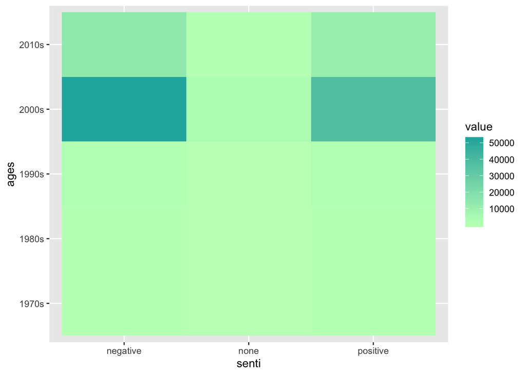

### Lyrics length

Compute how many words in one song using original lyrics.

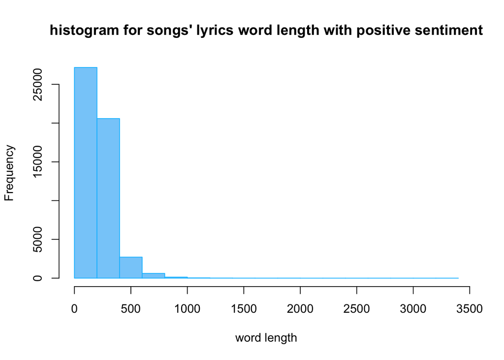

```
##
##  One-sample Kolmogorov-Smirnov test
##
## data:  lyrics3$length[lyrics3$senti == "positive"]
## D = 1, p-value < 2.2e-16
## alternative hypothesis: two-sided
```

```
##                   Df    Sum Sq Mean Sq F value Pr(>F)
## factor(senti)      2 1.783e+07 8915035   407.6 <2e-16 ***
## Residuals     125701 2.749e+09   21872
## ---
## Signif. codes:  0 '***' 0.001 '**' 0.01 '*' 0.05 '.' 0.1 ' ' 1
```

```
##   Tukey multiple comparisons of means
##     95% family-wise confidence level
##
## Fit: aov(formula = length ~ factor(senti), data = lyrics3)
##
## $`factor(senti)`
##                        diff       lwr       upr p adj
## none-negative     -34.51069 -39.64208 -29.37930 0e+00
## positive-negative -22.47056 -24.48810 -20.45302 0e+00
## positive-none      12.04013   6.84913  17.23113 2e-07
```

```
##
##  Pearson's product-moment correlation
##
## data:  dt_lyrics$score and dt_lyrics$length
## t = -37.7, df = 125702, p-value < 2.2e-16
## alternative hypothesis: true correlation is not equal to 0
## 95 percent confidence interval:
##  -0.1111991 -0.1002666
## sample estimates:
##        cor
## -0.1057361
```